# GAM modelling with mgcv and mgcViz

Matteo Fasiolo

June 10 2025

# Modelling the GEFCom14 data (part II, with mgcViz)

Load data and have a look at it:

```r
library(testGam)
data("gefcom_small")
head(gefcom_small)   # wM_s95[t] = 0.95 * wM_s95[t-1] + 0.05 * wM[t]
```

```
##   Year NetDemand       wM       Posan        Trend Dow    wM_s95 NetDemand.24
## 1 2005  2.889407 16.38889 0.001370019 0.0000000000   6  8.236849     2.889407
## 2 2005  2.543342 17.36111 0.004110058 0.0003961965   0  9.933947     2.889407
## 3 2005  2.446159 18.88889 0.006850097 0.0007923930   1 10.794862     2.543342
## 4 2005  2.190166 21.25000 0.009590136 0.0011885895   2 14.462260     2.446159
## 5 2005  2.100094 20.83333 0.012330175 0.0015847861   3 16.194613     2.190166
## 6 2005  2.130908 20.83333 0.015070213 0.0019809826   4 16.341327     2.100094
```

We divide into a train and a testing data set:

```r
train <- gefcom_small[gefcom_small$Year < 2011, ]
test <- gefcom_small[gefcom_small$Year == 2011, ]
```

Fit a basic Gaussian GAM:

```r
library(mgcv)
fit1 <- gam(formula = NetDemand ~ NetDemand.24 + Dow + Trend +
                      wM + wM_s95 + s(Posan, bs = "cc"),
            data = train)
```

Visualise all the effects with mgcv:

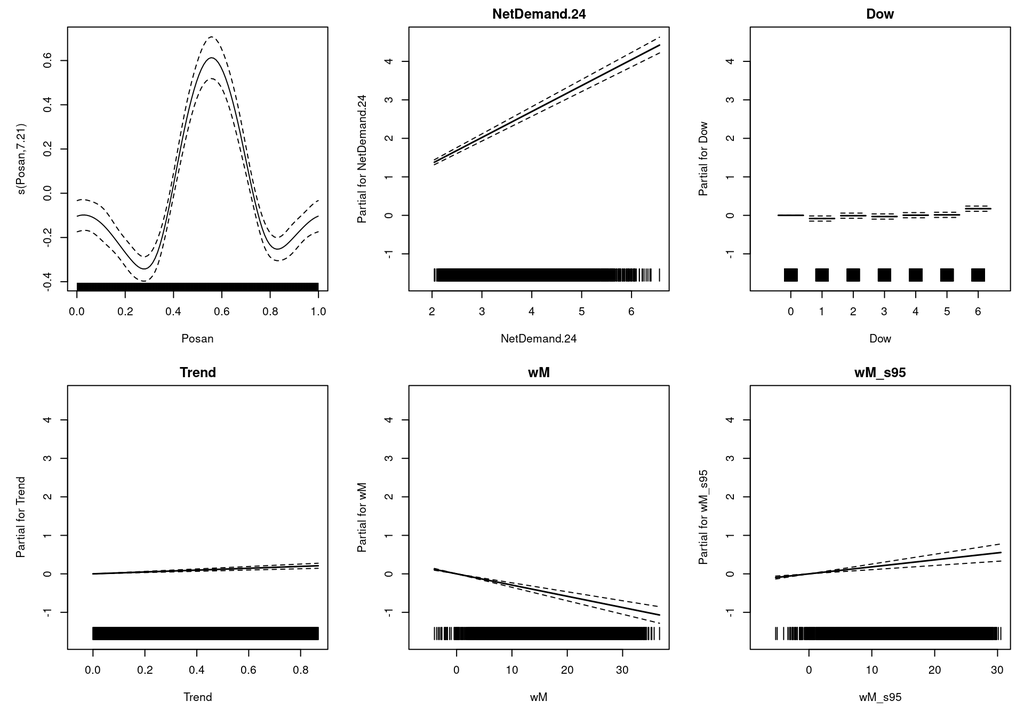

```r
plot(fit1, all.terms = TRUE, pages = 1)
```

Given that

```r
class(fit1)
```

```
## [1] "gam" "glm" "lm"
```

The generic `plot` calls `mgcv::plot.gam()` which is a method for the `gam` class:

```r
args(plot.gam)
```

```
## function (x, residuals = FALSE, rug = NULL, se = TRUE, pages = 0,
##     select = NULL, scale = -1, n = 100, n2 = 40, n3 = 3, theta = 30,
##     phi = 30, jit = FALSE, xlab = NULL, ylab = NULL, main = NULL,
##     ylim = NULL, xlim = NULL, too.far = 0.1, all.terms = FALSE,
##     shade = FALSE, shade.col = "gray80", shift = 0, trans = I,
##     seWithMean = FALSE, unconditional = FALSE, by.resids = FALSE,
##     scheme = 0, ...)
## NULL
```

Limitations of `plot.gam`:

- quite a lot of arguments
- order of graphical layers is fixed
- difficult to change graphical settings via `...`
- difficult to add new layers

`mgcViz` solves these problems using a layered system based on `ggplot2`. To use it, we need to object of class `gamViz`

```r
library(mgcViz)
fit1 <- getViz(fit1, nsim = 100)

class(fit1)
```

```
## [1] "gamViz" "gam"    "glm"    "lm"
```

Visualise all terms:

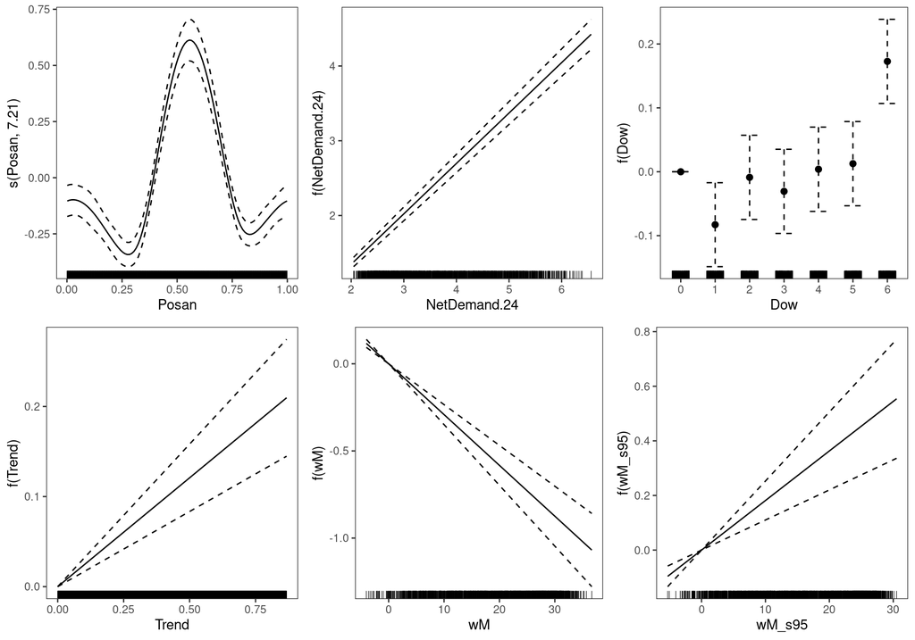

```r
print(plot(fit1, allTerms = TRUE), pages = 1)
```

Should we model temperature non-linearly? Before we did:

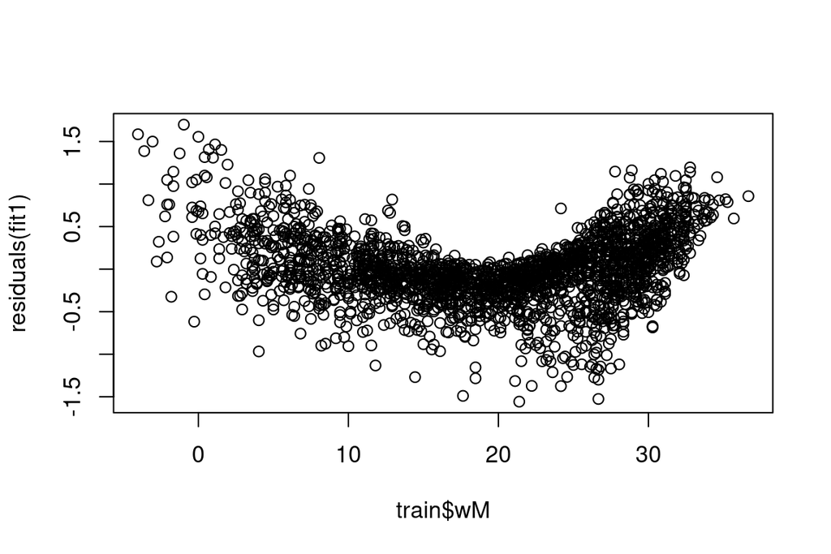

```r
plot(train$wM, residuals(fit1))
```

With `mgcViz` we can do:

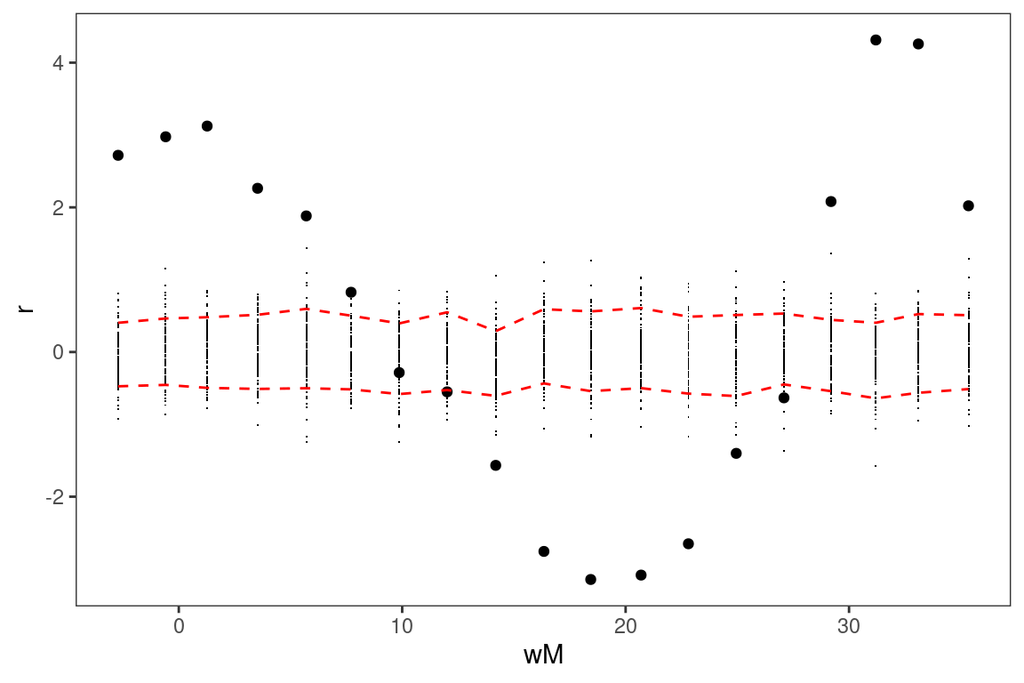

```r
check1D(fit1, "wM") + l_gridCheck1D()
```

It seems so. Update the model and check again:

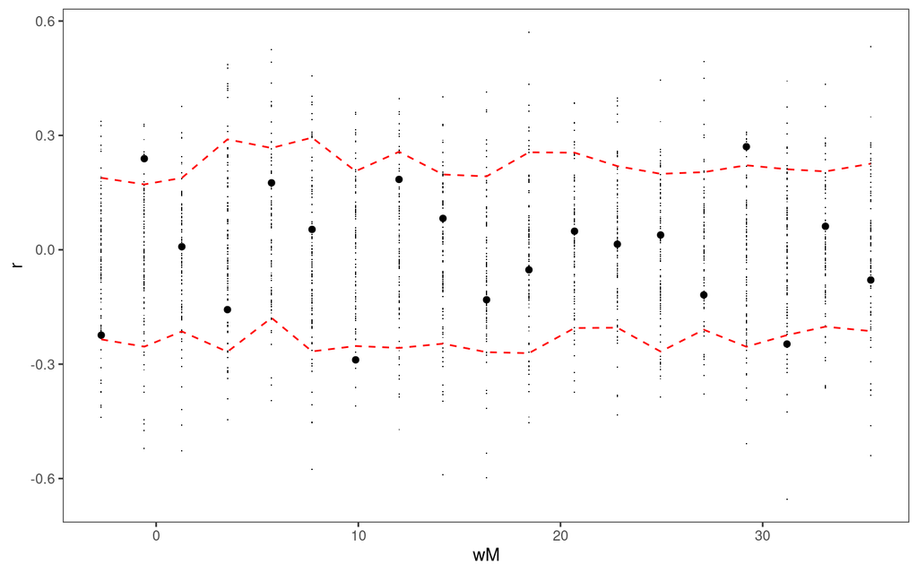

```r
fit2 <- gam(formula = NetDemand ~ NetDemand.24 + Dow + Trend +
                       s(wM) + s(wM_s95) + s(Posan, bs = "cc"),
             data = train)

fit2 <- getViz(fit2, nsim = 100)

check1D(fit2, "wM") + l_gridCheck1D()
```

Now it looks good.

Note that instead of doing `gam(formula = ...)` and then convert with `getViz`, we use the `gamV` short cut as here:

```r
fit2 <- gamV(formula = NetDemand ~ NetDemand.24 + Dow + Trend +
                       s(wM) + s(wM_s95) + s(Posan, bs = "cc"),
             data = train,
             aViz = list(nsim = 100))
```

The `mgcViz` equivalent of `gam.check` is:

```r
check(fit2)
```

```
##
## Method: REML   Optimizer: outer newton
## full convergence after 6 iterations.
## Gradient range [-6.944025e-05,6.196274e-05]
## (score -476.5933 & scale 0.03516541).
## Hessian positive definite, eigenvalue range [3.329995,1089.539].
## Model rank =  35 / 35
##
## Basis dimension (k) checking results. Low p-value (k-index<1) may
## indicate that k is too low, especially if edf is close to k'.
##
##             k'  edf k-index p-value
## s(wM)     9.00 8.59    0.94  <2e-16 ***
## s(wM_s95) 9.00 8.11    1.03    0.89
## s(Posan)  8.00 7.67    1.02    0.81
## ---
## Signif. codes:  0 '***' 0.001 '**' 0.01 '*' 0.05 '.' 0.1 ' ' 1
```

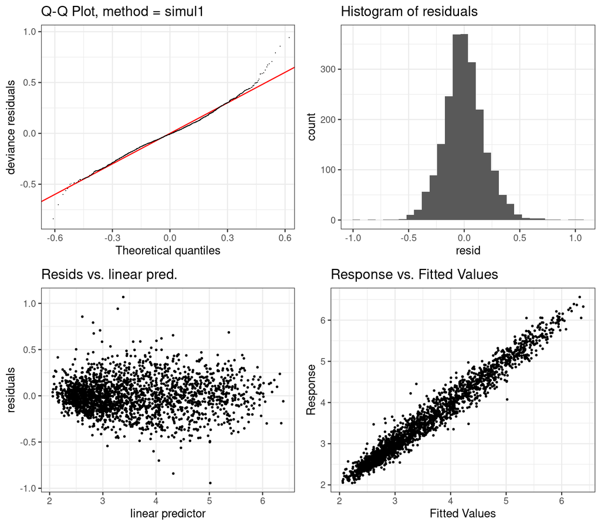

To get a qq-plot of the residuals we can do:

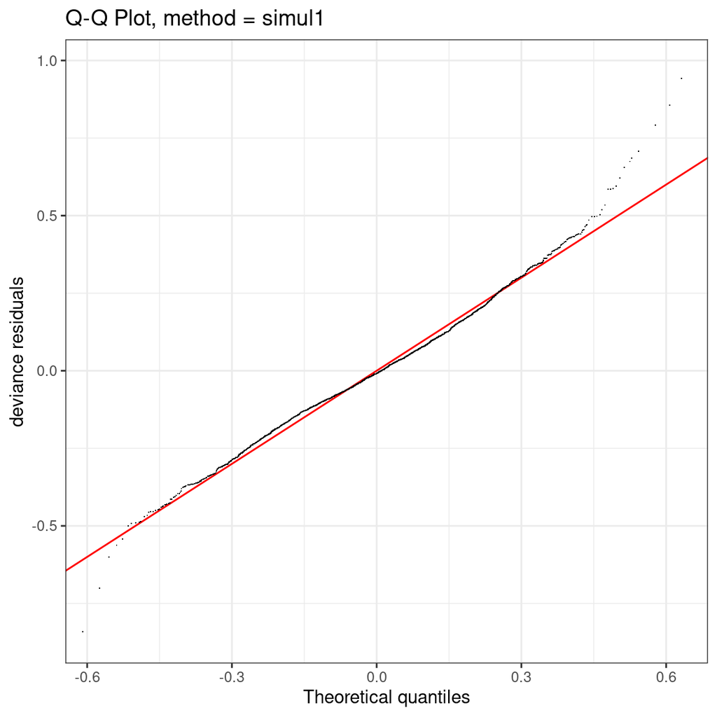

```r
qq(fit2)
```

# Larynx cancer in Germany

Load the data (see `?gamair::Larynx` for details)

```r
library(testGam)
library(mgcv)
data("Larynx")

head(Larynx)
```

```
##   region         E  Y  x
## 1      0  7.965008  8 56
## 2      1 22.836219 22 65
## 3      2 22.094716 19 50
## 4      3  7.919352  3 63
## 5      4 13.139889 14 65
## 6      5 15.898848  9 51
```

Load geometry of regions

```r
data("german.polys")
str(german.polys[1:5])
```

```
## List of 5
##  $ 0: num [1:10, 1:2] 2535 2554 2577 2577 2592 ...
##  $ 1: num [1:20, 1:2] 2988 2955 2934 2967 2924 ...
##  $ 2: num [1:30, 1:2] 3490 3498 3537 3498 3476 ...
##  $ 3: num [1:10, 1:2] 2927 2871 2871 2876 2859 ...
##  $ 4: num [1:46, 1:2] 2363 2377 2426 2440 2516 ...
```

Calculate regions’ centres and add them to data set

```r
X <- t( sapply(german.polys, colMeans, na.rm=TRUE) )
Larynx$lo <- X[ , 1]
Larynx$la <- X[ , 2]
```

Now fit model including only the effect of smoking

```r
fit1 <- gamV(Y ~ s(x, k=20),
             family = poisson,
             data=Larynx,
             aViz = list(nsim = 100))
```

Check mean residuals, binned across space

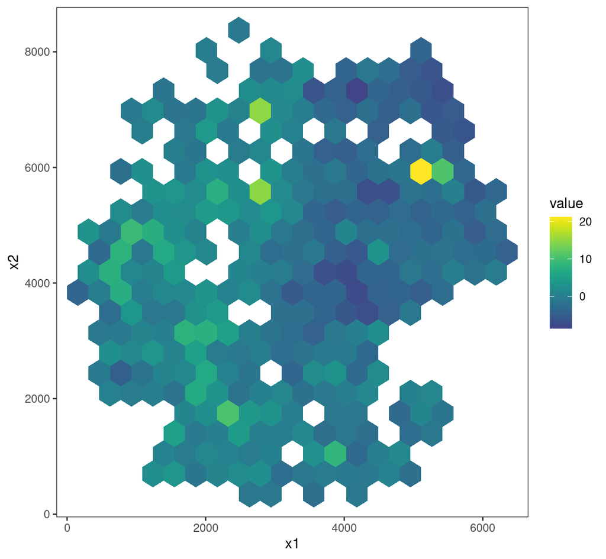

```r
check2D(fit1, x1 = Larynx$lo, x2 = Larynx$la) + l_gridCheck2D()
```

The massive positive outlier is Berlin! We forgot the offset
$$\mathbb{E}(N_r|x) = E_r \exp\{ f(x_r) \}, \;\;\; \text{or} \;\;\;
\log\mathbb{E}(N_r|x) = f(x_r) + \log E_r$$
that is, the number of cancers should be proportional to the population of each region. We correct the model

```r
fit2 <- gamV(Y ~ s(x, k=20) + offset( log(E) ),
             family = poisson,
             data=Larynx,
             aViz = list(nsim = 100))
```

Repeat the check

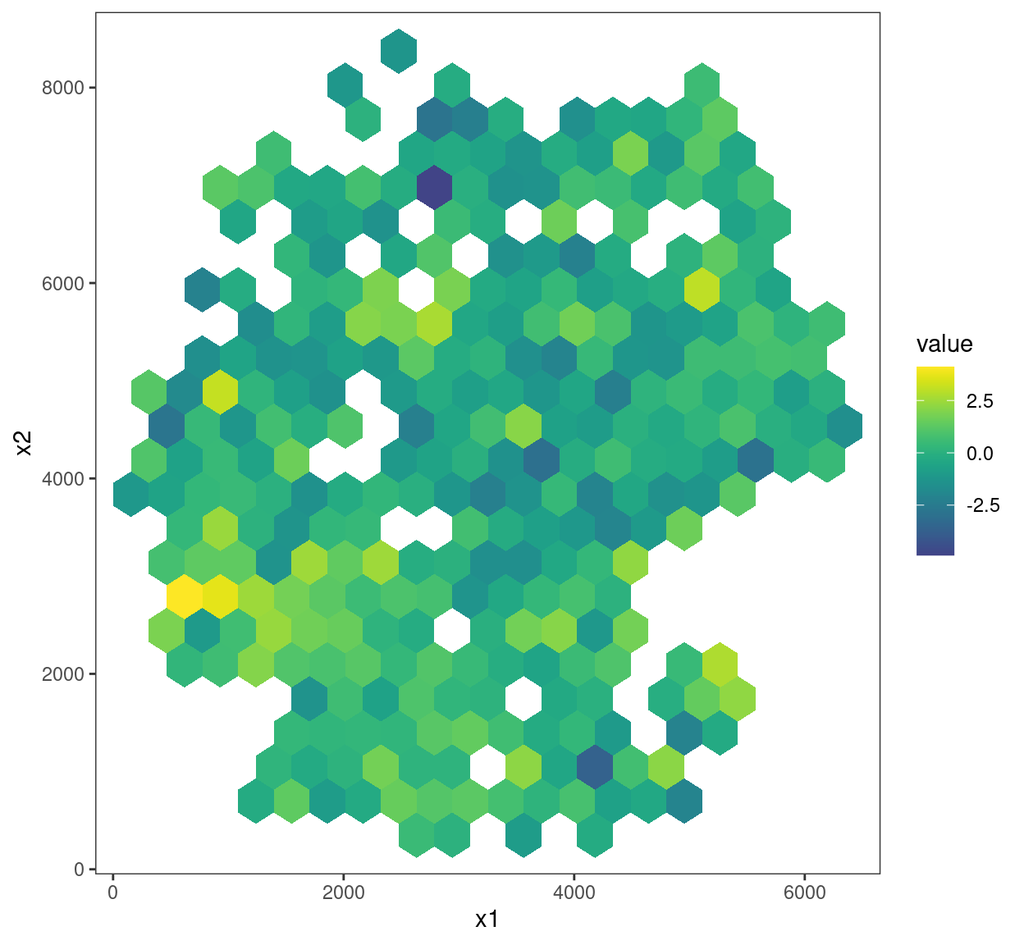

```r
check2D(fit2, x1 = Larynx$lo, x2 = Larynx$la) + l_gridCheck2D()
```

There is still some spatial effect.

Add MRF effect to capture spatial effect

```r
fit3 <- gamV(Y ~ s(region, k = 200, bs="mrf", xt=list(polys=german.polys)) +
                 s(x, k=20) + offset( log(E) ),
             family = poisson,
             data=Larynx,
             aViz = list(nsim = 100))
```

Repeat the checks and compare

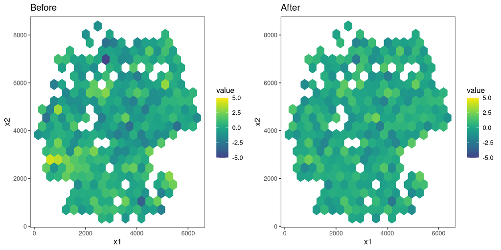

```r
library(viridis)
ck1 <- check2D(fit2, x1 = Larynx$lo, x2 = Larynx$la) + l_gridCheck2D() + ggtitle("Before") +
       scale_fill_gradientn(colours = viridis(50, begin = 0.2), limits = c(-5, 5))

ck2 <- check2D(fit3, x1 = Larynx$lo, x2 = Larynx$la) + l_gridCheck2D() + ggtitle("After")  +
       scale_fill_gradientn(colours = viridis(50, begin = 0.2), limits = c(-5, 5))

gridPrint(ck1, ck2, ncol = 2)
```

Looks better! We look at the spatial effect

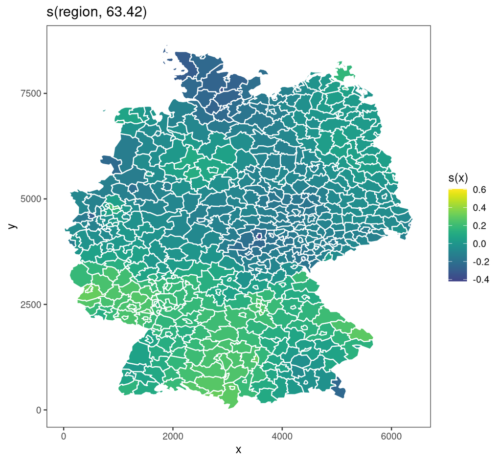

```r
plot(fit3, select = 1)
```

Now we use an isotropic smooth instead

```r
fitISO <- gamV(Y ~ s(lo, la, k = 200) +
                 s(x, k=20) + offset( log(E) ),
             family = poisson,
             data=Larynx)
```

Visualise the effect

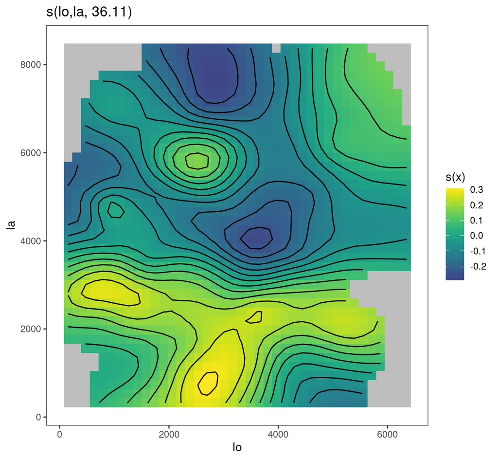

```r
plot(fitISO, select = 1)
```

Visualise in 3D using `rgl` package

```r
plotRGL( sm(fitISO, 1), residuals = TRUE )
```

[interactive chart not shown]

NB: `plotRGL` is not layered, it is a classic function

```r
args(plotRGL.mgcv.smooth.2D)
```

```
## function (x, se = TRUE, n = 40, residuals = FALSE, type = "auto",
##     maxpo = 1000, too.far = 0, xlab = NULL, ylab = NULL, main = NULL,
##     xlim = NULL, ylim = NULL, se.mult = 1, trans = identity,
##     seWithMean = FALSE, unconditional = FALSE, ...)
## NULL
```